# Report COVID study POOLED V100

## 9.2 Gender

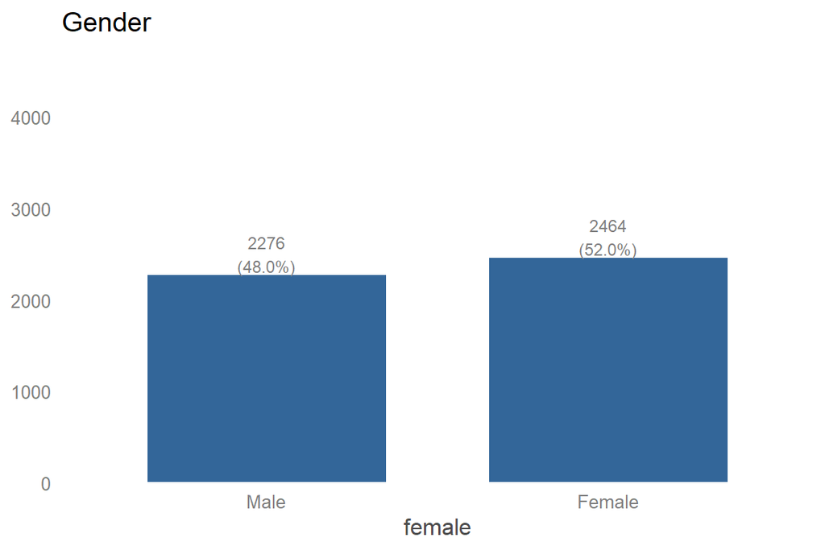

```r
pooled %>%
plot_frq(female,
                ylim = c(0,nrow(pooled)),
        axis.labels = c("Male","Female"),
        title = "Gender")+
  theme_blank()
```

## 9.3 Education

Not included yet.

## 9.4 Income

Not included yet.

## 9.5 Province

Not included yet.

## 9.6 Works in healthcare sector

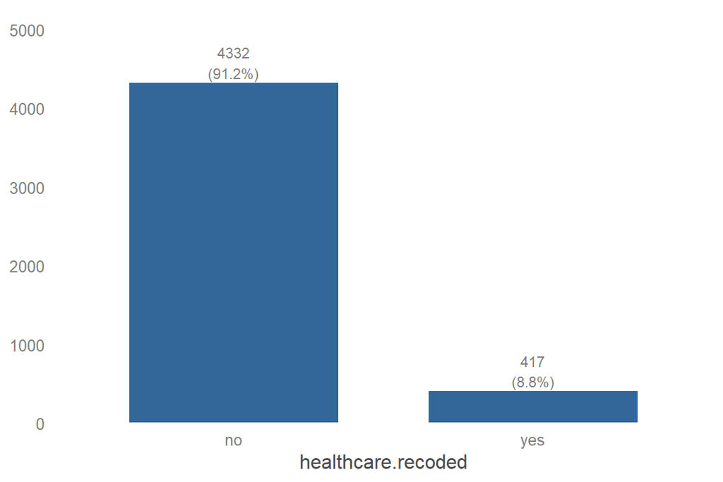

```r
pooled %>%
  plot_frq(healthcare.recoded,
        ylim = c(0,nrow(pooled)+500),
        title = "") +
  theme_blank()
```

# 10 Pre-post

## 10.1 Distribution of credibility EMA (post)

```r
pooled %>% count(credibility.EMA.post) %>%
  mutate(percentage = (n/(sum(n))*100))  %>%
  adorn_totals("row") %>%
    kable(col.names = c("Credibility EMA (post)",
                        "n",
                        "%")
          , digits = 2) %>%
    kable_styling(bootstrap_options = c("condensed", "striped", "hover"),
                full_width = F,
                position = "left")
```

| Credibility EMA (post) | n | % |
| --- | --- | --- |
| 1 | 60 | 1.26 |
| 2 | 56 | 1.18 |
| 3 | 132 | 2.78 |
| 4 | 501 | 10.55 |
| 5 | 519 | 10.93 |
| 6 | 500 | 10.53 |
| 7 | 361 | 7.60 |
| NA | 2620 | 55.17 |
| Total | 4749 | 100.00 |

As this variable was added later to the survey, there is substantial missing data for this variable.

## 10.2 Plot

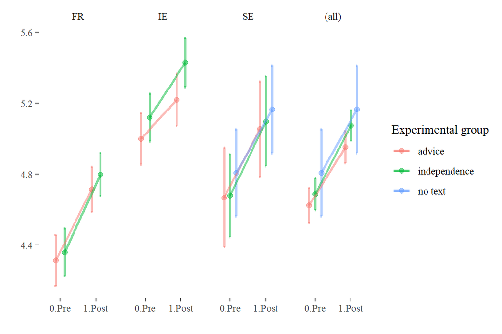

```r
t26 <- pooled  %>%
  select(experimental.group,
         credibility.EMA.pre,
         credibility.EMA.post,
         country) %>% drop_na(credibility.EMA.post) %>%
  gather("key","value",-experimental.group, -country) %>%
  mutate(key = recode(key,"'credibility.EMA.pre'='0.Pre';'credibility.EMA.post'='1.Post'"))

t26 %>% ggplot(aes(x=key,y=value,color=experimental.group))+
      stat_summary(fun.data = mean_cl_normal, geom = "errorbar", alpha=0.5,width=0.1,size=1,position=position_dodge(0.5)) +
  stat_summary(fun = mean, geom = "point", alpha=0.5,size=2,position=position_dodge(0.5))+
  stat_summary(fun = mean, geom = "line", alpha=0.5,size=1,position=position_dodge(0.5), aes(group = experimental.group)) + labs(color ='Experimental group', x = "", y = "") + facet_grid(~country, margins = TRUE) +
  theme_tufte()
```

## 10.3 Regression

### 10.3.1 Total

**Models**

```r
prepost.total <- pooled %>% mutate(id = row_number()) %>%
  select(experimental.group,
         id,
         credibility.EMA.pre,
         credibility.EMA.post,
         country) %>%
  drop_na() %>%
  gather("key","value",-experimental.group,-id,-country) %>%
  mutate(post = key %>% Recode("'credibility.EMA.pre'= 0;'credibility.EMA.post'=1"),
         credibility = value)


m1 <- lmer(credibility ~ post + (1|id),
                       data = prepost.total)

m2 <- m1 %>% update(.~.+experimental.group)


m3 <- m2 %>% update(.~. + post*experimental.group)


tab_model(m2, m3,
          show.ci = F,
          show.se = T,
          collapse.se = T,
          emph.p = F)
```

|  | credibility |  | credibility |  |
| --- | --- | --- | --- | --- |
| Predictors | Estimates | p | Estimates | p |
| (Intercept) | 4.61 (0.04) | <0.001 | 4.62 (0.05) | <0.001 |
| post | 0.36 (0.03) | <0.001 | 0.33 (0.04) | <0.001 |
| experimental.group [independence] | 0.09 (0.06) | 0.119 | 0.06 (0.07) | 0.335 |
| experimental.group [no text] | 0.20 (0.13) | 0.124 | 0.18 (0.14) | 0.198 |
| post * experimental.group [independence] |  |  | 0.06 (0.06) | 0.303 |
| post * experimental.group [no text] |  |  | 0.03 (0.12) | 0.812 |
| Random Effects |  |  |  |  |
| σ<sup>2</sup> | 0.81 |  | 0.81 |  |
| τ<sub>00</sub> | 1.38 <sub>id</sub> |  | 1.38 <sub>id</sub> |  |
| ICC | 0.63 |  | 0.63 |  |
| N | 2129 <sub>id</sub> |  | 2129 <sub>id</sub> |  |
| Observations | 4258 |  | 4258 |  |
| Marginal R<sup>2</sup> / Conditional R<sup>2</sup> | 0.016 / 0.637 |  | 0.016 / 0.636 |  |

**Interaction effect**

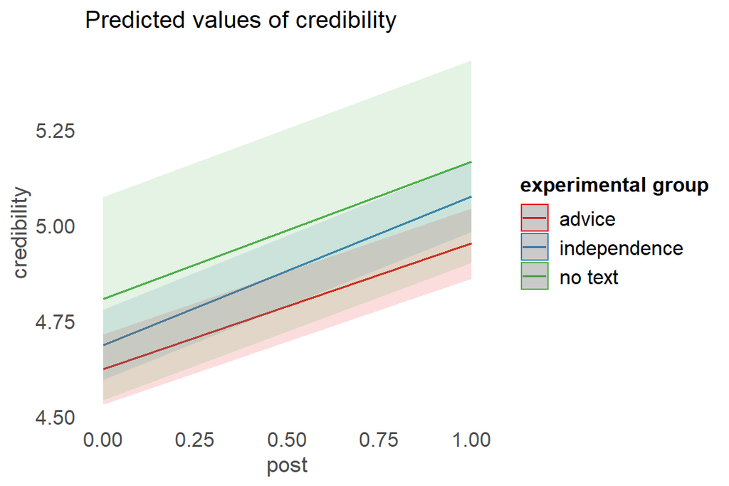

```r
plot_model(m3, type = "int")
```

### 10.3.2 Ireland

**Models**

```r
prepost.IE <- prepost.total %>% filter(country == "IE")

m5 <- lmer(credibility ~ post + (1|id), data = prepost.IE)

m6 <- m5 %>% update(.~.+experimental.group)

m7 <- m6 %>% update(.~. + post*experimental.group)

tab_model(m6, m7,
          show.ci = F,
          show.se = T,
          collapse.se = T,
          emph.p = F)
```

|  | credibility |  | credibility |  |
| --- | --- | --- | --- | --- |
| Predictors | Estimates | p | Estimates | p |
| (Intercept) | 4.98 (0.07) | <0.001 | 5.00 (0.07) | <0.001 |
| post | 0.26 (0.05) | <0.001 | 0.22 (0.07) | 0.001 |
| experimental.group [independence] | 0.16 (0.09) | 0.069 | 0.12 (0.10) | 0.239 |
| post * experimental.group [independence] |  |  | 0.09 (0.09) | 0.332 |
| Random Effects |  |  |  |  |
| σ<sup>2</sup> | 0.82 |  | 0.82 |  |
| τ<sub>00</sub> | 1.17 <sub>id</sub> |  | 1.17 <sub>id</sub> |  |
| ICC | 0.59 |  | 0.59 |  |
| N | 770 <sub>id</sub> |  | 770 <sub>id</sub> |  |
| Observations | 1540 |  | 1540 |  |
| Marginal R<sup>2</sup> / Conditional R<sup>2</sup> | 0.012 / 0.593 |  | 0.012 / 0.593 |  |

**Interaction effect**

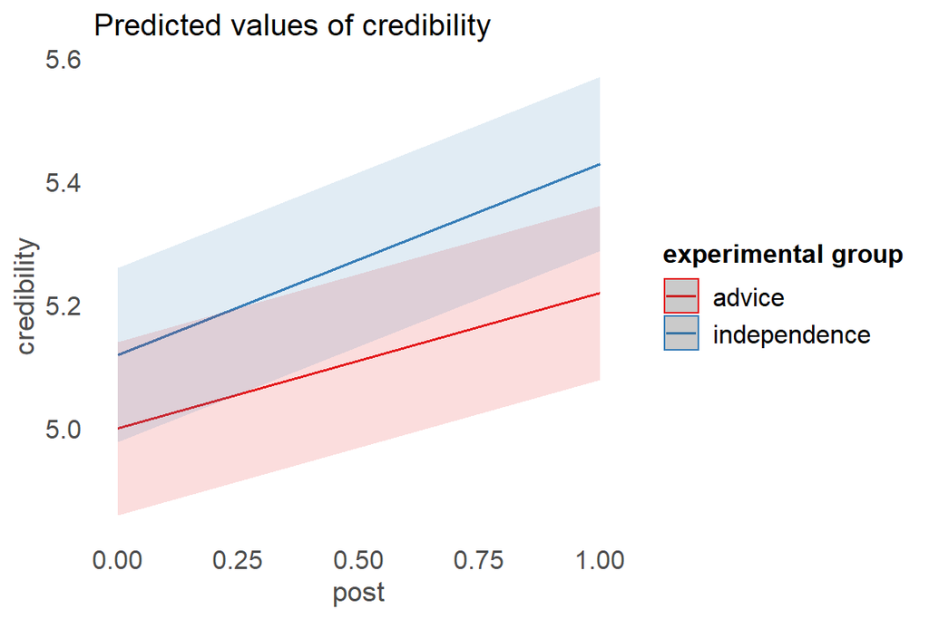

```r
plot_model(m7, type = "int")
```

### 10.3.3 Sweden

```r
prepost.SE <- prepost.total %>% filter(country == "SE")

m8 <- lmer(credibility ~ post + (1|id),
                       data = prepost.SE)

m9 <- m8 %>% update(.~.+ experimental.group)

m10 <- m9 %>% update(.~. + post*experimental.group)

tab_model(m9, m10,
          show.ci = F,
          show.se = T,
          collapse.se = T,
          emph.p = F)
```

|  | credibility |  | credibility |  |
| --- | --- | --- | --- | --- |
| Predictors | Estimates | p | Estimates | p |
| (Intercept) | 4.67 (0.12) | <0.001 | 4.67 (0.13) | <0.001 |
| post | 0.39 (0.06) | <0.001 | 0.39 (0.10) | <0.001 |
| experimental.group [independence] | 0.03 (0.17) | 0.871 | 0.01 (0.18) | 0.952 |
| experimental.group [no text] | 0.13 (0.17) | 0.454 | 0.14 (0.18) | 0.447 |
| post * experimental.group [independence] |  |  | 0.03 (0.15) | 0.826 |
| post * experimental.group [no text] |  |  | -0.03 (0.15) | 0.852 |
| Random Effects |  |  |  |  |
| σ<sup>2</sup> | 0.67 |  | 0.67 |  |
| τ<sub>00</sub> | 1.40 <sub>id</sub> |  | 1.40 <sub>id</sub> |  |
| ICC | 0.68 |  | 0.68 |  |
| N | 369 <sub>id</sub> |  | 369 <sub>id</sub> |  |
| Observations | 738 |  | 738 |  |
| Marginal R<sup>2</sup> / Conditional R<sup>2</sup> | 0.019 / 0.684 |  | 0.019 / 0.682 |  |

**Interaction effect**

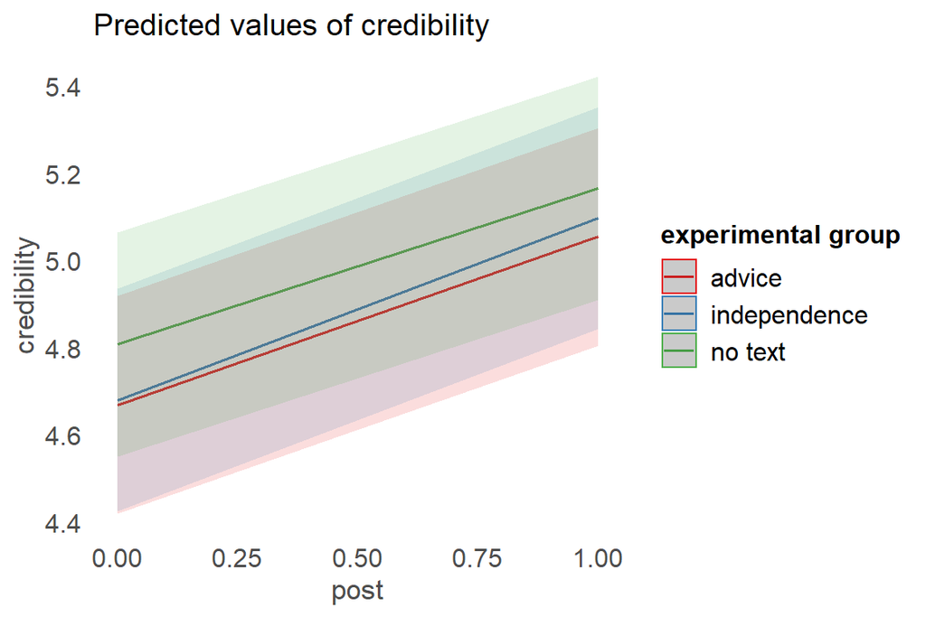

```r
plot_model(m10, type = "int")
```

### 10.3.4 France

**Models**

```r
prepost.FR <- prepost.total %>% filter(country == "FR")

m11 <- lmer(credibility ~ post + (1|id),
                       data = prepost.FR)

m12 <- m11 %>% update(.~.+ experimental.group)

m13 <- m12 %>% update(.~. + post*experimental.group)

tab_model(m12, m13,
          show.ci = F,
          show.se = T,
          collapse.se = T,
          emph.p = F)
```

|  | credibility |  | credibility |  |
| --- | --- | --- | --- | --- |
| Predictors | Estimates | p | Estimates | p |
| (Intercept) | 4.30 (0.06) | <0.001 | 4.31 (0.07) | <0.001 |
| post | 0.42 (0.04) | <0.001 | 0.40 (0.06) | <0.001 |
| experimental.group [independence] | 0.07 (0.09) | 0.445 | 0.05 (0.09) | 0.630 |
| post * experimental.group [independence] |  |  | 0.04 (0.08) | 0.639 |
| Random Effects |  |  |  |  |
| σ<sup>2</sup> | 0.85 |  | 0.85 |  |
| τ<sub>00</sub> | 1.37 <sub>id</sub> |  | 1.37 <sub>id</sub> |  |
| ICC | 0.62 |  | 0.62 |  |
| N | 990 <sub>id</sub> |  | 990 <sub>id</sub> |  |
| Observations | 1980 |  | 1980 |  |
| Marginal R<sup>2</sup> / Conditional R<sup>2</sup> | 0.020 / 0.624 |  | 0.020 / 0.624 |  |

**Interaction effect**

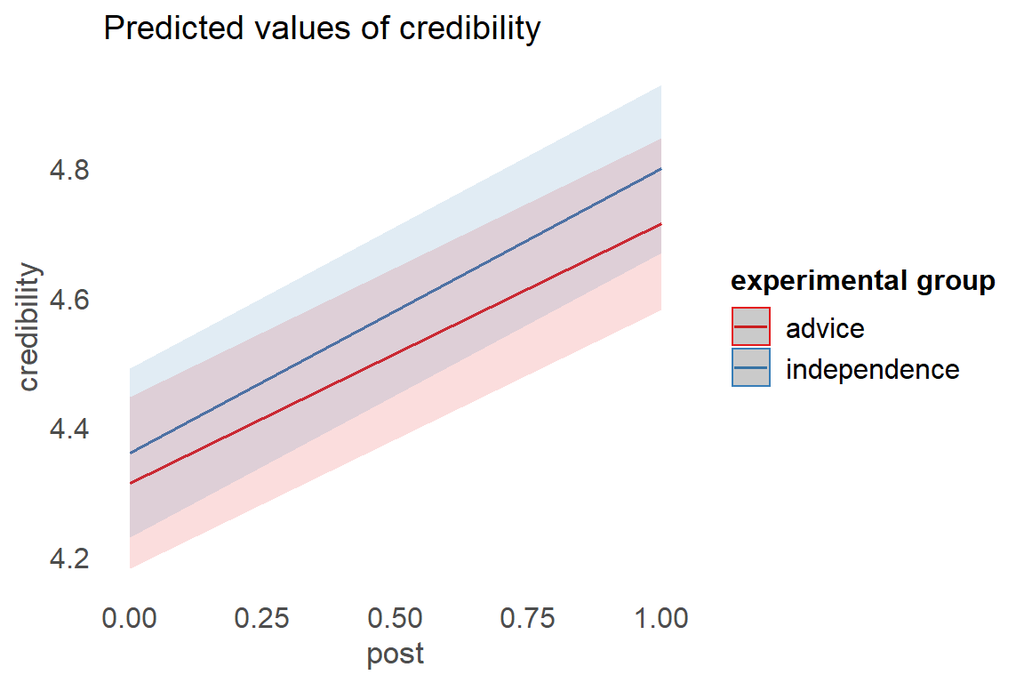

```r
plot_model(m13, type = "int")
```

# 11 Explaining perceived political independence

```r
pooled.regression <- pooled # To do: select variables included in regression model

r1.1 <- lm(perceived.independence.reversed ~
         trust.EU.institutions +
         trust.scientist +
         trust.politicians +
         political.ideology +
         EU.integration +
         interpersonal.trust +
         familiarity.EMA +
         familiarity.advice +
         credibility.EMA.pre +
         trust.health.authorities +
         consequences.health +
         consequences.economic +
         importance.EMA.recoded +
         importance.FDA.recoded +
         importance.NRA.recoded +
         private.providers +
         knowledge +
         benefits.vaccines,
                    data = pooled.regression,
                    na.action = na.omit)


r1.2 <- stats::update(r1.1, . ~ . + experimental.group)

r1.3 <- stats::update(r1.2, . ~ . +
        female +
         healthcare +
         poly(age, 2) +
         country)

r1.4 <- stats::update(r1.3, . ~ . + trust.media)

stargazer(r1.1,
          r1.2,
          r1.3,
          r1.4,
  report = "vcsp",
  style = "apsr",
  omit.stat = c("ser", "f"),
  type = "html",
  dep.var.labels = "Perceived political independence",
  initial.zero = FALSE,
  notes = "*Notes*: Table entries are non-standardized OLS-regression coefficients, with standard errors in parentheses.",
  notes.append = FALSE
)
```

|  | Perceived political independence |  |  |  |
| --- | --- | --- | --- | --- |
|  | (1) | (2) | (3) | (4) |
| trust.EU.institutions | .043 | .044 | .051 | .078 |
|  | (.024) | (.024) | (.024) | (.039) |
|  | p = .071 | p = .061 | p = .033 | p = .047 |
| trust.scientist | -.071 | -.072 | -.063 | -.039 |
|  | (.020) | (.020) | (.020) | (.034) |
|  | p = .001 | p = .0005 | p = .002 | p = .256 |
| trust.politicians | -.007 | -.007 | -.003 | .023 |
|  | (.017) | (.017) | (.018) | (.031) |
|  | p = .700 | p = .705 | p = .862 | p = .449 |
| political.ideology | -.063 | -.064 | -.060 | -.073 |
|  | (.015) | (.015) | (.015) | (.026) |
|  | p = .00003 | p = .00003 | p = .0001 | p = .005 |
| EU.integration | -.009 | -.011 | -.004 | -.031 |
|  | (.015) | (.015) | (.015) | (.025) |
|  | p = .553 | p = .484 | p = .821 | p = .219 |
| interpersonal.trust | -.020 | -.021 | -.027 | -.047 |
|  | (.014) | (.014) | (.014) | (.023) |
|  | p = .139 | p = .133 | p = .053 | p = .047 |
| familiarity.EMA | -.071 | -.070 | -.075 | -.046 |
|  | (.016) | (.016) | (.016) | (.024) |
|  | p = .00002 | p = .00002 | p = .00001 | p = .055 |
| familiarity.advice | .028 | .029 | .011 | -.017 |
|  | (.016) | (.016) | (.016) | (.024) |
|  | p = .076 | p = .058 | p = .494 | p = .470 |
| credibility.EMA.pre | .101 | .101 | .098 | .125 |
|  | (.022) | (.022) | (.022) | (.037) |
|  | p = .00001 | p = .00001 | p = .00001 | p = .001 |
| trust.health.authorities | .035 | .035 | .024 | .041 |
|  | (.017) | (.017) | (.017) | (.030) |

[output cut: 62 more lines]

# 12 Explaining vaccination intention

## 12.1 Distribution of variable

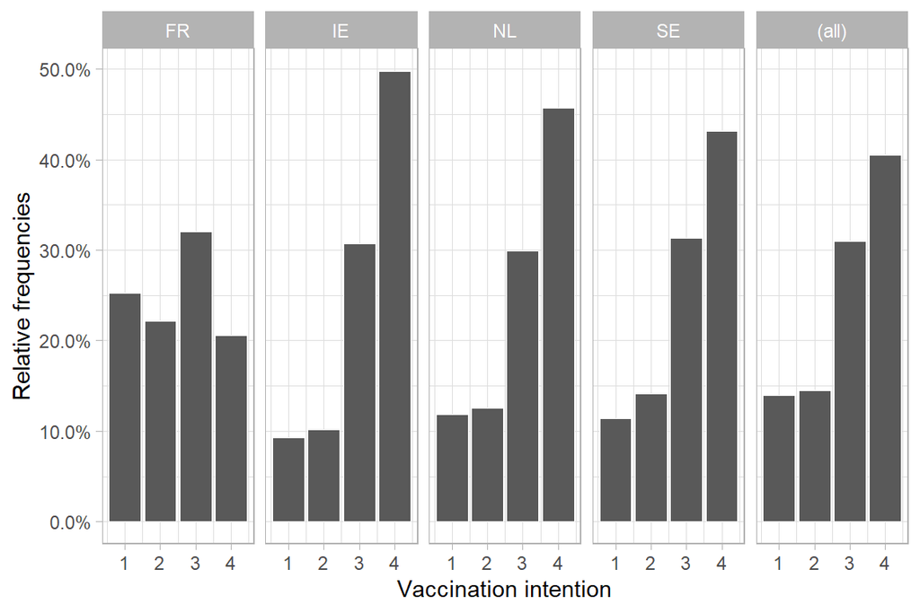

```r
pooled  %>%
  ggplot(aes(intent.vaccine, group = country)) +
          geom_bar(aes(y = ..prop..), stat="count") +
          scale_y_continuous(labels=scales::percent) +
          labs(y = "Relative frequencies", x = "Vaccination intention") +
          facet_grid(~country, margins = TRUE) + theme_light()
```

This variable has been recoded. Answer categories 1 and 2 are recoded as 0. Answer caterogies 3 and 4 are recoded as 1.

## 12.2 Regression models

```r
r2.1 <- glm(intent.vaccine.recoded ~ credibility.index,
                    data = pooled.regression,
                    na.action = na.omit,
                    family = binomial(link = 'logit'))


r2.2 <- stats::update(r2.1, . ~ . +
         trust.EU.institutions +
         trust.scientist +
         trust.politicians +
         political.ideology +
         EU.integration +
         interpersonal.trust +
         familiarity.EMA +
         familiarity.advice +
         credibility.EMA.pre +
         trust.health.authorities +
         consequences.health +
         consequences.economic +
         importance.EMA.recoded +
         importance.FDA.recoded +
         importance.NRA.recoded +
         private.providers +
         knowledge +
         benefits.vaccines)

r2.3 <- stats::update(r2.2, . ~ . +
          female +
         healthcare +
         poly(age, 2) +
         country)

r2.4 <- stats::update(r2.3, . ~ . +
                        trust.media)

stargazer(r2.1,
          r2.2,
          r2.3,
          r2.4,
  report = "vcsp",
  style = "apsr",
  omit.stat = c("ser", "f"),
  type = "html",
  dep.var.labels = "Vaccination intention",
  initial.zero = FALSE,
  notes = "*Notes*: Generalized Linear Model",
  notes.append = FALSE
)
```

|  | Vaccination intention |  |  |  |
| --- | --- | --- | --- | --- |
|  | (1) | (2) | (3) | (4) |
| credibility.index | 1.346 | .586 | .595 | .560 |
|  | (.047) | (.060) | (.063) | (.093) |
|  | p = 0.000 | p = 0.000 | p = 0.000 | p = 0.000 |
| trust.EU.institutions |  | -.055 | .043 | .107 |
|  |  | (.052) | (.054) | (.078) |
|  |  | p = .283 | p = .427 | p = .171 |
| trust.scientist |  | -.0002 | -.004 | .081 |
|  |  | (.042) | (.043) | (.066) |
|  |  | p = .998 | p = .921 | p = .219 |
| trust.politicians |  | -.011 | -.046 | -.030 |
|  |  | (.037) | (.039) | (.063) |
|  |  | p = .778 | p = .242 | p = .629 |
| political.ideology |  | .050 | .033 | .118 |
|  |  | (.033) | (.034) | (.052) |
|  |  | p = .128 | p = .323 | p = .023 |
| EU.integration |  | .009 | .066 | .021 |
|  |  | (.033) | (.035) | (.050) |
|  |  | p = .793 | p = .057 | p = .678 |
| interpersonal.trust |  | .114 | .052 | .104 |
|  |  | (.031) | (.032) | (.048) |
|  |  | p = .0003 | p = .105 | p = .032 |
| familiarity.EMA |  | -.026 | .006 | -.001 |
|  |  | (.036) | (.037) | (.049) |
|  |  | p = .470 | p = .874 | p = .989 |
| familiarity.advice |  | .098 | .016 | .040 |
|  |  | (.035) | (.036) | (.049) |
|  |  | p = .006 | p = .665 | p = .419 |
| credibility.EMA.pre |  | -.163 | -.194 | -.211 |
|  |  | (.047) | (.049) | (.074) |

[output cut: 59 more lines]

# 13 Explaning crebility of EMA’s opinion

## 13.1 Stability

### 13.1.1 Distribution of variable

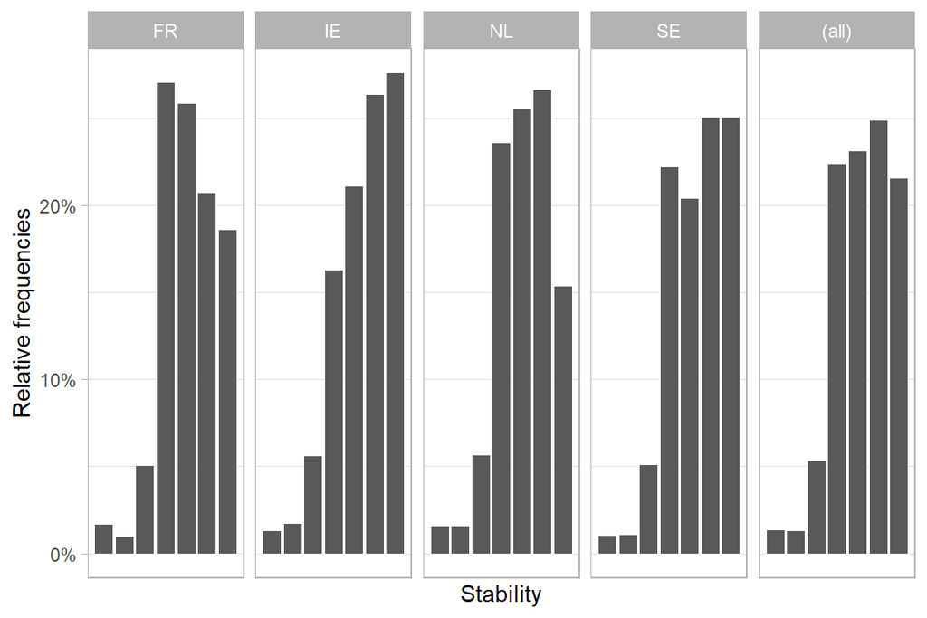

```r
pooled %>%
  ggplot(aes(stability, group = country)) +
          geom_bar(aes(y = ..prop..), stat="count") +
          scale_y_continuous(labels=scales::percent) +
          scale_x_continuous(breaks = NULL) +
          labs(y = "Relative frequencies", x = "Stability") +
          facet_grid(~country, margins = TRUE) + theme_light()
```

### 13.1.2 Effect of the manipulation

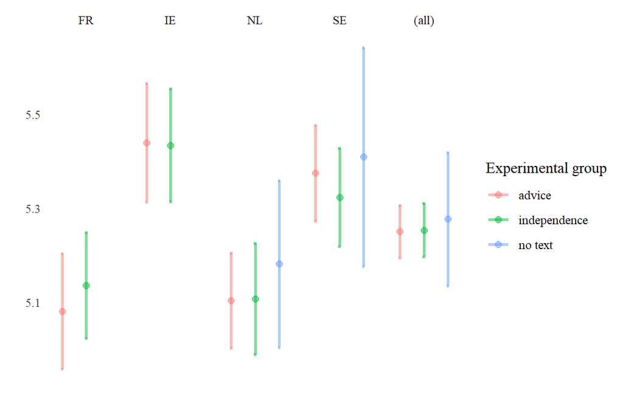

```r
pooled  %>% ggplot(aes(x = experimental.group, y = stability, color = experimental.group)) +
      stat_summary(fun.data = mean_cl_normal, geom = "errorbar", alpha = 0.5, width = 0.1, size = 1, position = position_dodge(0.5)) + labs(color ='Experimental group', x = "", y = "") +
    stat_summary(fun = mean, geom = "point", alpha = 0.5, size = 2 , position = position_dodge(0.5)) +  facet_grid(.~country, margins = TRUE) +  theme_tufte() + theme(axis.text.x = element_blank(), axis.ticks = element_blank())
```

## 13.2 Regression models

```r
r3.1 <- lm(stability  ~ perceived.independence.reversed +
         trust.EU.institutions +
         trust.scientist +
         trust.politicians +
         political.ideology +
         EU.integration +
         interpersonal.trust +
         familiarity.EMA +
         familiarity.advice +
         credibility.EMA.pre +
         trust.health.authorities +
         consequences.health +
         consequences.economic +
         importance.EMA.recoded +
         importance.FDA.recoded +
         importance.NRA.recoded +
         private.providers +
         knowledge +
         benefits.vaccines +
        female +
         healthcare +
         poly(age, 2) +
         country,
                    data = pooled,
                    na.action = na.omit)

r3.2 <- stats::update(r3.1, . ~ . -
            perceived.independence.reversed +
            experimental.group)

r3.3 <- stats::update(r3.1, . ~ . +
            benefits.vaccines:perceived.independence.reversed) %>% meanCenter(centerOnlyInteractors = TRUE, centerDV = FALSE)

r3.4 <- stats::update(r3.2, . ~ . +
            benefits.vaccines:experimental.group) %>% meanCenter(centerOnlyInteractors = TRUE, centerDV = FALSE)

stargazer(r3.1,
          r3.3,
          r3.2,
          r3.4,
  report = "vcsp",
  style = "apsr",
  omit.stat = c("ser", "f"),
  type = "html",
  dep.var.labels = "Stability",
  initial.zero = FALSE,
  notes = "*Notes*: Table entries are non-standardized OLS-regression coefficients, with standard errors in parentheses.",
  notes.append = FALSE
)
```

|  | Stability |  |  |  |
| --- | --- | --- | --- | --- |
|  | (1) | (2) | (3) | (4) |
| perceived.independence.reversed | -.065 |  |  |  |
|  | (.012) |  |  |  |
|  | p = 0.00000 |  |  |  |
| perceived.independence.reversedc |  | -.068 |  |  |
|  |  | (.012) |  |  |
|  |  | p = 0.00000 |  |  |
| trust.EU.institutions | -.009 | -.007 | -.012 | -.012 |
|  | (.020) | (.020) | (.021) | (.021) |
|  | p = .675 | p = .731 | p = .551 | p = .548 |
| trust.scientist | .088 | .080 | .092 | .092 |
|  | (.017) | (.017) | (.017) | (.017) |
|  | p = 0.00000 | p = .00001 | p = 0.00000 | p = 0.00000 |
| trust.politicians | -.007 | -.006 | -.007 | -.007 |
|  | (.015) | (.015) | (.015) | (.015) |
|  | p = .636 | p = .699 | p = .635 | p = .635 |
| political.ideology | .002 | .004 | .006 | .006 |
|  | (.013) | (.013) | (.013) | (.013) |
|  | p = .853 | p = .764 | p = .624 | p = .626 |
| EU.integration | -.018 | -.017 | -.018 | -.018 |
|  | (.013) | (.013) | (.013) | (.013) |
|  | p = .171 | p = .188 | p = .171 | p = .171 |
| interpersonal.trust | .037 | .035 | .039 | .039 |
|  | (.012) | (.012) | (.012) | (.012) |
|  | p = .002 | p = .004 | p = .002 | p = .001 |
| familiarity.EMA | -.023 | -.020 | -.018 | -.018 |
|  | (.014) | (.014) | (.014) | (.014) |
|  | p = .106 | p = .155 | p = .201 | p = .205 |
| familiarity.advice | .102 | .097 | .102 | .102 |
|  | (.014) | (.014) | (.014) | (.014) |

[output cut: 77 more lines]

```r
# Trust in media not yet included.
```

**Interaction effect: Perceived political independence X Benefits of vaccines**

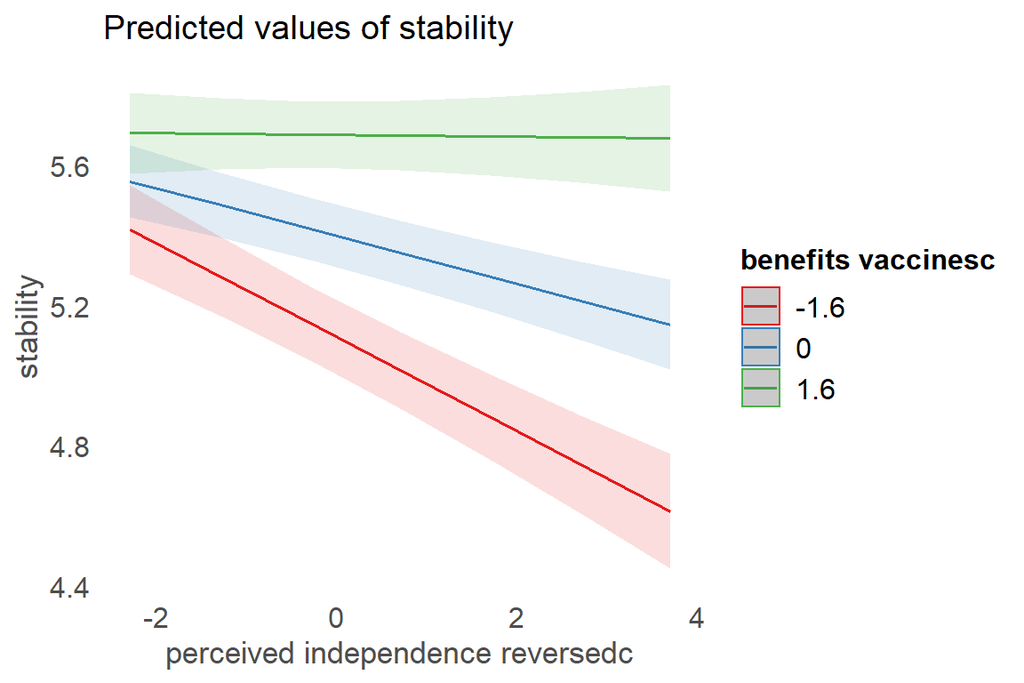

```r
plot_model(r3.3, type = "int", mdrt.values = "meansd")
```

## 13.3 Expertise

### 13.3.1 Distribution of variable

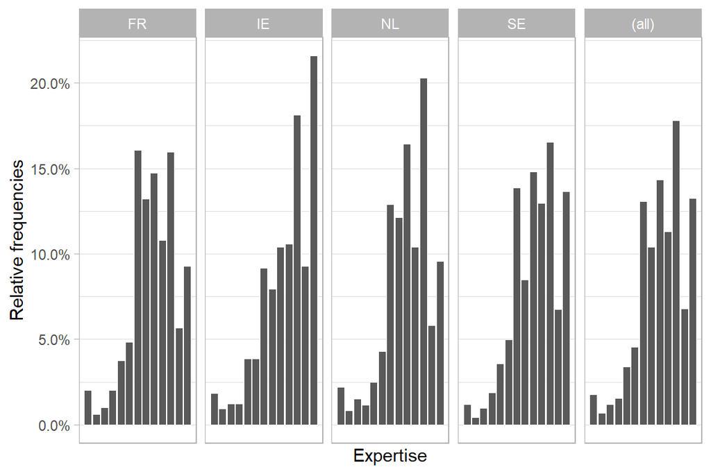

```r
pooled %>%
  ggplot(aes(expertise, group = country)) +
          geom_bar(aes(y = ..prop..), stat="count") +
          scale_y_continuous(labels=scales::percent) +
          scale_x_continuous(breaks = NULL) +
          labs(y = "Relative frequencies", x = "Expertise") +
          facet_grid(~country, margins = TRUE) + theme_light()
```

### 13.3.2 Effect of the manipulation

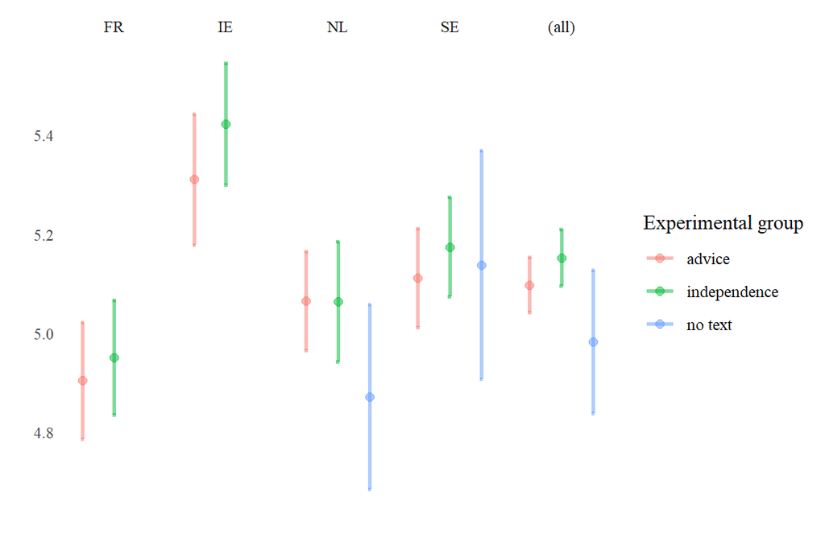

```r
pooled  %>% ggplot(aes(x = experimental.group, y = expertise, color = experimental.group)) +
      stat_summary(fun.data = mean_cl_normal, geom = "errorbar", alpha = 0.5, width = 0.1, size = 1, position = position_dodge(0.5)) + labs(color ='Experimental group', x = "", y = "") +
    stat_summary(fun = mean, geom = "point", alpha = 0.5, size = 2 , position = position_dodge(0.5)) +  facet_grid(.~country, margins = TRUE) +  theme_tufte() + theme(axis.text.x = element_blank(), axis.ticks = element_blank())
```

## 13.4 Regression models

```r
r4.1 <- lm(expertise  ~ perceived.independence.reversed +
         trust.EU.institutions +
         trust.scientist +
         trust.politicians +
         political.ideology +
         EU.integration +
         interpersonal.trust +
         familiarity.EMA +
         familiarity.advice +
         credibility.EMA.pre +
         trust.health.authorities +
         consequences.health +
         consequences.economic +
         importance.EMA.recoded +
         importance.FDA.recoded +
         importance.NRA.recoded +
         private.providers +
         knowledge +
         benefits.vaccines +
        female +
         healthcare +
         poly(age, 2) +
         country,
                    data = pooled,
                    na.action = na.omit)

r4.2 <- stats::update(r4.1, . ~ . -
            perceived.independence.reversed +
            experimental.group)

r4.3 <- stats::update(r4.1, . ~ . +
            benefits.vaccines:perceived.independence.reversed) %>% meanCenter(centerOnlyInteractors = TRUE, centerDV = FALSE)

r4.4 <- stats::update(r4.2, . ~ . +
            benefits.vaccines:experimental.group) %>% meanCenter(centerOnlyInteractors = TRUE, centerDV = FALSE)

stargazer(r4.1,
          r4.3,
          r4.2,
          r4.4,
  report = "vcsp",
  style = "apsr",
  omit.stat = c("ser", "f"),
  type = "html",
  dep.var.labels = "Expertise",
  initial.zero = FALSE,
  notes = "*Notes*: Table entries are non-standardized OLS-regression coefficients, with standard errors in parentheses.",
  notes.append = FALSE
)
```

|  | Expertise |  |  |  |
| --- | --- | --- | --- | --- |
|  | (1) | (2) | (3) | (4) |
| perceived.independence.reversed | .018 |  |  |  |
|  | (.010) |  |  |  |
|  | p = .060 |  |  |  |
| perceived.independence.reversedc |  | .018 |  |  |
|  |  | (.010) |  |  |
|  |  | p = .066 |  |  |
| trust.EU.institutions | .025 | .025 | .027 | .026 |
|  | (.016) | (.016) | (.016) | (.016) |
|  | p = .115 | p = .112 | p = .093 | p = .097 |
| trust.scientist | .084 | .083 | .083 | .083 |
|  | (.013) | (.013) | (.013) | (.013) |
|  | p = 0.000 | p = 0.000 | p = 0.000 | p = 0.000 |
| trust.politicians | -.021 | -.021 | -.021 | -.021 |
|  | (.012) | (.012) | (.012) | (.012) |
|  | p = .071 | p = .074 | p = .070 | p = .073 |
| political.ideology | .014 | .014 | .013 | .013 |
|  | (.010) | (.010) | (.010) | (.010) |
|  | p = .150 | p = .145 | p = .185 | p = .183 |
| EU.integration | .039 | .039 | .039 | .038 |
|  | (.010) | (.010) | (.010) | (.010) |
|  | p = .0002 | p = .0002 | p = .0002 | p = .0002 |
| interpersonal.trust | .028 | .028 | .027 | .027 |
|  | (.009) | (.009) | (.009) | (.009) |
|  | p = .003 | p = .003 | p = .003 | p = .004 |
| familiarity.EMA | .008 | .008 | .007 | .006 |
|  | (.011) | (.011) | (.011) | (.011) |
|  | p = .478 | p = .457 | p = .546 | p = .553 |
| familiarity.advice | .046 | .046 | .047 | .047 |
|  | (.010) | (.010) | (.010) | (.010) |

[output cut: 77 more lines]

```r
# Trust in media not yet included.
```

**Interaction effect: Perceived political independence X Benefits of vaccines**

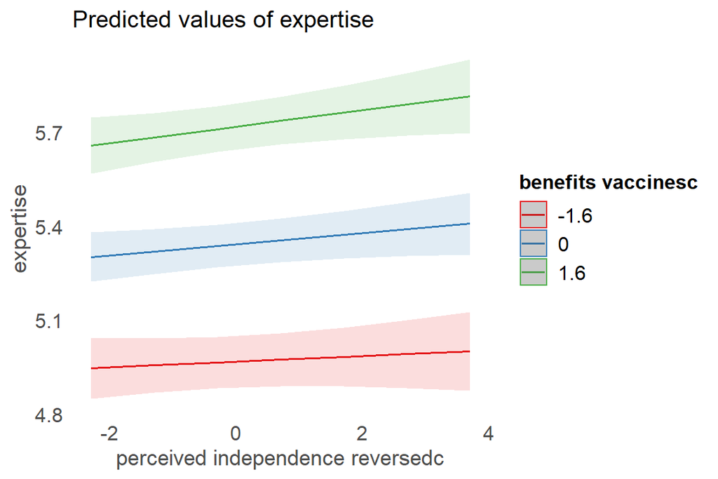

```r
plot_model(r4.3, type = "int", mdrt.values = "meansd")
```

## 13.5 Non-interference

### 13.5.1 Distribution of variable

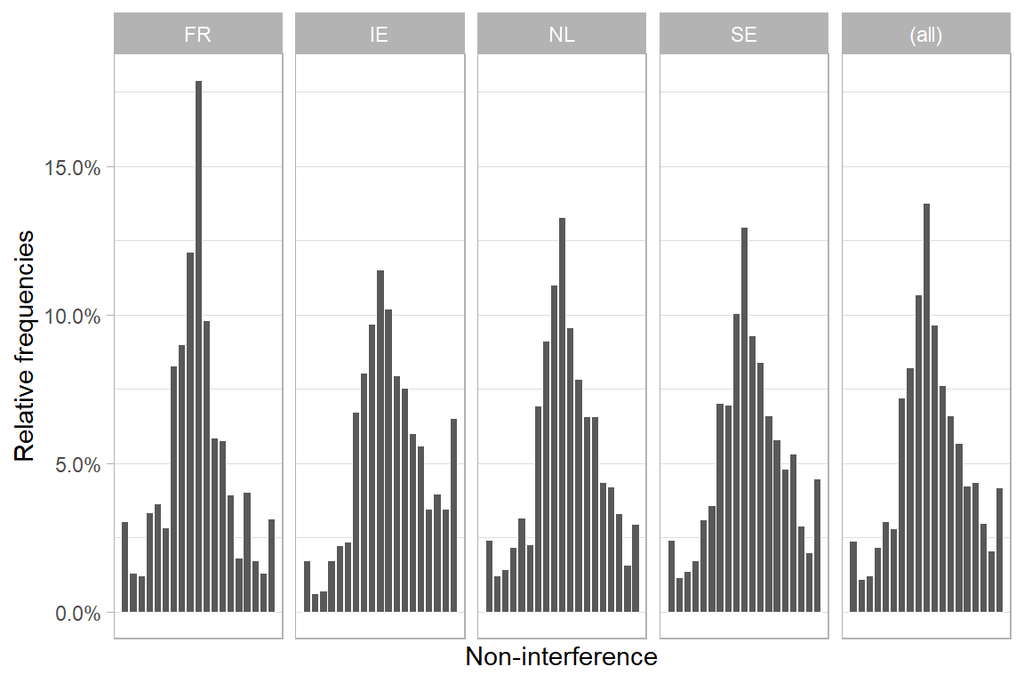

```r
pooled %>%
  ggplot(aes(noninterference, group = country)) +
          geom_bar(aes(y = ..prop..), stat="count") +
          scale_y_continuous(labels=scales::percent) +
          scale_x_continuous(breaks = NULL) +
          labs(y = "Relative frequencies", x = "Non-interference") +
          facet_grid(~country, margins = TRUE) + theme_light()
```

### 13.5.2 Effect of the manipulation

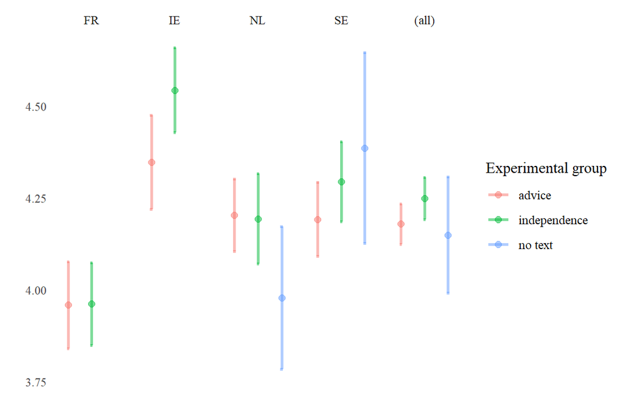

```r
pooled  %>% ggplot(aes(x = experimental.group, y = noninterference, color = experimental.group)) +
      stat_summary(fun.data = mean_cl_normal, geom = "errorbar", alpha = 0.5, width = 0.1, size = 1, position = position_dodge(0.5)) + labs(color ='Experimental group', x = "", y = "") +
    stat_summary(fun = mean, geom = "point", alpha = 0.5, size = 2 , position = position_dodge(0.5)) +  facet_grid(.~country, margins = TRUE) +  theme_tufte() + theme(axis.text.x = element_blank(), axis.ticks = element_blank())
```

## 13.6 Regression models

```r
r5.1 <- lm(noninterference  ~ perceived.independence.reversed +
         trust.EU.institutions +
         trust.scientist +
         trust.politicians +
         political.ideology +
         EU.integration +
         interpersonal.trust +
         familiarity.EMA +
         familiarity.advice +
         credibility.EMA.pre +
         trust.health.authorities +
         consequences.health +
         consequences.economic +
         importance.EMA.recoded +
         importance.FDA.recoded +
         importance.NRA.recoded +
         private.providers +
         knowledge +
         benefits.vaccines +
        female +
         healthcare +
         poly(age, 2) +
         country,
                    data = pooled,
                    na.action = na.omit)

r5.2 <- stats::update(r5.1, . ~ . -
            perceived.independence.reversed +
            experimental.group)

r5.3 <- stats::update(r5.1, . ~ . +
            benefits.vaccines:perceived.independence.reversed) %>% meanCenter(centerOnlyInteractors = TRUE, centerDV = FALSE)

r5.4 <- stats::update(r5.2, . ~ . +
            benefits.vaccines:experimental.group) %>% meanCenter(centerOnlyInteractors = TRUE, centerDV = FALSE)

stargazer(r5.1,
          r5.3,
          r5.2,
          r5.4,
  report = "vcsp",
  style = "apsr",
  omit.stat = c("ser", "f"),
  type = "html",
  dep.var.labels = "Non-interference",
  initial.zero = FALSE,
  notes = "*Notes*: Table entries are non-standardized OLS-regression coefficients, with standard errors in parentheses.",
  notes.append = FALSE
)
```

|  | Non-interference |  |  |  |
| --- | --- | --- | --- | --- |
|  | (1) | (2) | (3) | (4) |
| perceived.independence.reversed | .268 |  |  |  |
|  | (.010) |  |  |  |
|  | p = 0.000 |  |  |  |
| perceived.independence.reversedc |  | .267 |  |  |
|  |  | (.010) |  |  |
|  |  | p = 0.000 |  |  |
| trust.EU.institutions | -.003 | -.002 | .011 | .012 |
|  | (.017) | (.017) | (.018) | (.018) |
|  | p = .862 | p = .897 | p = .543 | p = .516 |
| trust.scientist | .016 | .012 | -.001 | -.001 |
|  | (.014) | (.014) | (.015) | (.015) |
|  | p = .265 | p = .384 | p = .948 | p = .948 |
| trust.politicians | .019 | .020 | .018 | .018 |
|  | (.012) | (.012) | (.013) | (.013) |
|  | p = .124 | p = .112 | p = .168 | p = .177 |
| political.ideology | -.012 | -.012 | -.029 | -.029 |
|  | (.011) | (.011) | (.011) | (.011) |
|  | p = .241 | p = .268 | p = .012 | p = .011 |
| EU.integration | .049 | .050 | .048 | .049 |
|  | (.011) | (.011) | (.012) | (.012) |
|  | p = .00001 | p = .00001 | p = .00004 | p = .00003 |
| interpersonal.trust | .017 | .016 | .010 | .010 |
|  | (.010) | (.010) | (.010) | (.010) |
|  | p = .076 | p = .098 | p = .336 | p = .324 |
| familiarity.EMA | -.023 | -.022 | -.043 | -.043 |
|  | (.012) | (.012) | (.012) | (.012) |
|  | p = .045 | p = .058 | p = .0005 | p = .0005 |
| familiarity.advice | .023 | .021 | .026 | .026 |
|  | (.011) | (.011) | (.012) | (.012) |

[output cut: 77 more lines]

```r
# Trust in media not yet included.
```

**Interaction effect: Perceived political independence X Benefits of vaccines**

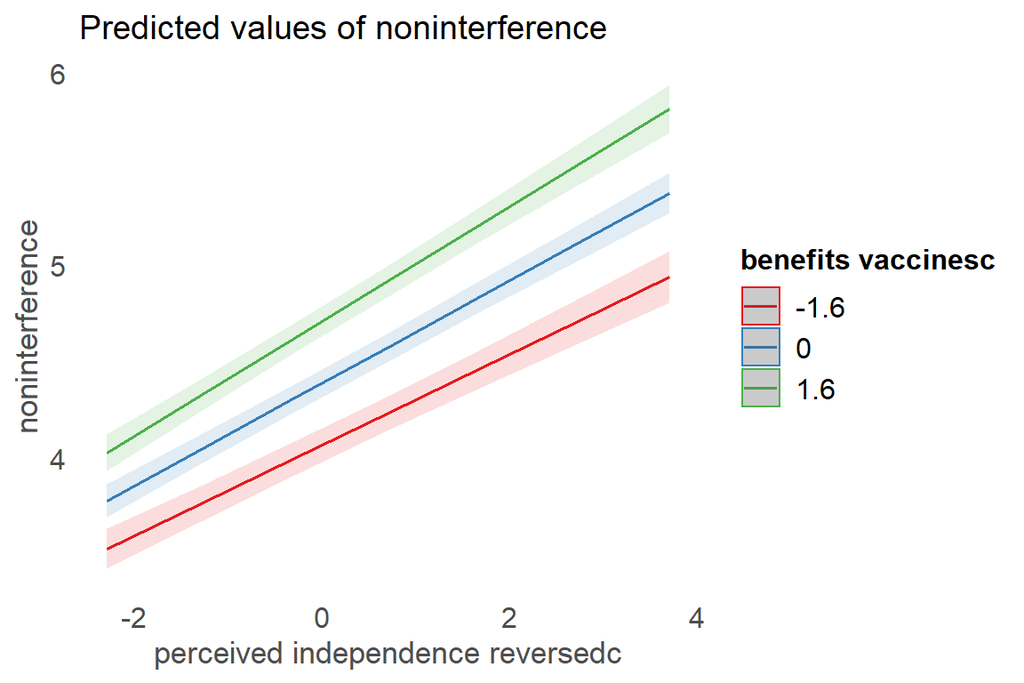

```r
plot_model(r5.3, type = "int", mdrt.values = "meansd")
```

## 13.7 Crebility index

### 13.7.1 Distribution of variable

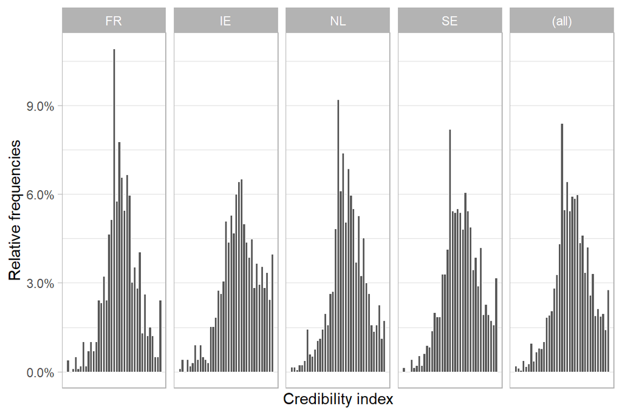

```r
pooled %>%
  ggplot(aes(credibility.index, group = country)) +
          geom_bar(aes(y = ..prop..), stat="count") +
          scale_y_continuous(labels=scales::percent) +
          scale_x_continuous(breaks = NULL) +
          labs(y = "Relative frequencies", x = "Credibility index") +
          facet_grid(~country, margins = TRUE) + theme_light()
```

### 13.7.2 Effect of the manipulation

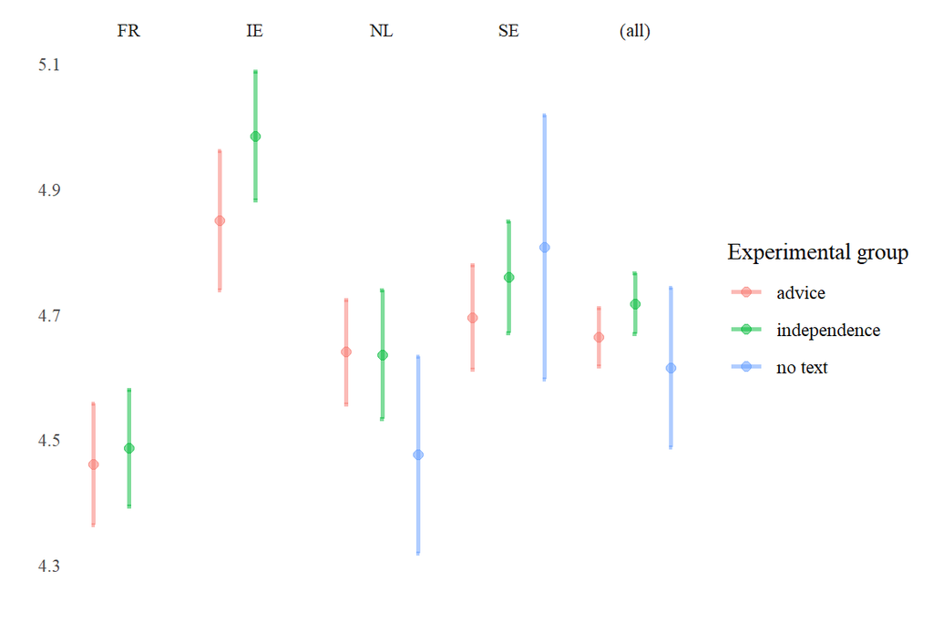

```r
pooled  %>% ggplot(aes(x = experimental.group, y = credibility.index, color = experimental.group)) +
      stat_summary(fun.data = mean_cl_normal, geom = "errorbar", alpha = 0.5, width = 0.1, size = 1, position = position_dodge(0.5)) + labs(color ='Experimental group', x = "", y = "") +
    stat_summary(fun = mean, geom = "point", alpha = 0.5, size = 2 , position = position_dodge(0.5)) +  facet_grid(.~country, margins = TRUE) +  theme_tufte() + theme(axis.text.x = element_blank(), axis.ticks = element_blank())
```

## 13.8 Regression models

```r
r6.1 <- lm(credibility.index  ~ perceived.independence.reversed +
         trust.EU.institutions +
         trust.scientist +
         trust.politicians +
         political.ideology +
         EU.integration +
         interpersonal.trust +
         familiarity.EMA +
         familiarity.advice +
         credibility.EMA.pre +
         trust.health.authorities +
         consequences.health +
         consequences.economic +
         importance.EMA.recoded +
         importance.FDA.recoded +
         importance.NRA.recoded +
         private.providers +
         knowledge +
         benefits.vaccines +
        female +
         healthcare +
         poly(age, 2) +
         country,
                    data = pooled,
                    na.action = na.omit)

r6.2 <- stats::update(r6.1, . ~ . -
            perceived.independence.reversed +
            experimental.group)

r6.3 <- stats::update(r6.1, . ~ . +
            benefits.vaccines:perceived.independence.reversed) %>% meanCenter(centerOnlyInteractors = TRUE, centerDV = FALSE)

r6.4 <- stats::update(r6.2, . ~ . +
            benefits.vaccines:experimental.group) %>% meanCenter(centerOnlyInteractors = TRUE, centerDV = FALSE)

stargazer(r6.1,
          r6.3,
          r6.2,
          r6.4,
  report = "vcsp",
  style = "apsr",
  omit.stat = c("ser", "f"),
  type = "html",
  dep.var.labels = "Credibility index",
  initial.zero = FALSE,
  notes = "*Notes*: Table entries are non-standardized OLS-regression coefficients, with standard errors in parentheses.",
  notes.append = FALSE
)
```

|  | Credibility index |  |  |  |
| --- | --- | --- | --- | --- |
|  | (1) | (2) | (3) | (4) |
| perceived.independence.reversed | .129 |  |  |  |
|  | (.008) |  |  |  |
|  | p = 0.000 |  |  |  |
| perceived.independence.reversedc |  | .128 |  |  |
|  |  | (.008) |  |  |
|  |  | p = 0.000 |  |  |
| trust.EU.institutions | .005 | .006 | .012 | .013 |
|  | (.013) | (.013) | (.013) | (.013) |
|  | p = .676 | p = .635 | p = .354 | p = .345 |
| trust.scientist | .051 | .047 | .042 | .042 |
|  | (.011) | (.011) | (.011) | (.011) |
|  | p = .00001 | p = .00002 | p = .0002 | p = .0002 |
| trust.politicians | .001 | .002 | .001 | .001 |
|  | (.009) | (.009) | (.010) | (.010) |
|  | p = .888 | p = .838 | p = .925 | p = .936 |
| political.ideology | -.001 | -.0004 | -.009 | -.009 |
|  | (.008) | (.008) | (.008) | (.008) |
|  | p = .898 | p = .963 | p = .285 | p = .284 |
| EU.integration | .034 | .035 | .034 | .034 |
|  | (.008) | (.008) | (.009) | (.009) |
|  | p = .00004 | p = .00003 | p = .0001 | p = .0001 |
| interpersonal.trust | .024 | .023 | .021 | .021 |
|  | (.007) | (.007) | (.008) | (.008) |
|  | p = .002 | p = .002 | p = .008 | p = .008 |
| familiarity.EMA | -.013 | -.012 | -.023 | -.023 |
|  | (.009) | (.009) | (.009) | (.009) |
|  | p = .146 | p = .190 | p = .014 | p = .013 |
| familiarity.advice | .044 | .042 | .046 | .045 |
|  | (.009) | (.009) | (.009) | (.009) |

[output cut: 77 more lines]

```r
# Trust in media not yet included.
```

**Interaction effect: Perceived political independence X Benefits of vaccines**

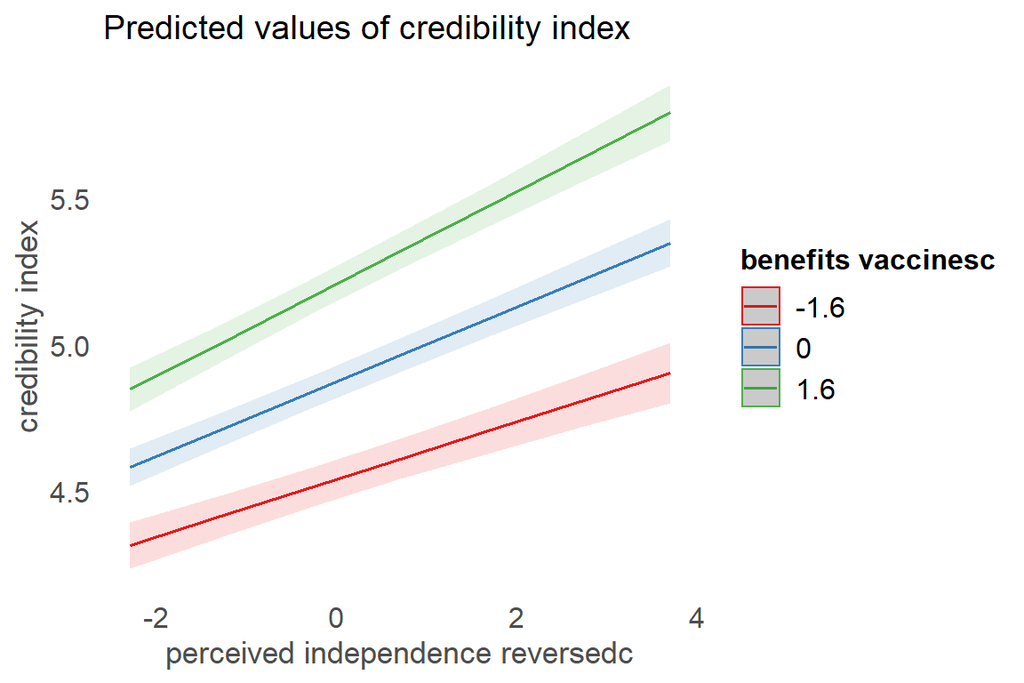

```r
plot_model(r6.3, type = "int", mdrt.values = "meansd")
```

# 14 Remarks from participants

## 14.1 General

```r
df.total %>%
  filter(nchar(comments.general)>1) %>%
  select(comments.general) %>%
  kable() %>%
  kable_styling(bootstrap_options = "striped", full_width = F) %>%    scroll_box(height = "400px")
```

[output not shown]

## 14.2 Vaccination intention

```r
pooled %>%
  filter(nchar(Q16.3)>1) %>%
  select(Q16.3) %>%
  kable() %>%
  kable_styling(bootstrap_options = "striped", full_width = F) %>%    scroll_box(height = "400px")
```

[output not shown]